# Species List Comparisons

### GBIF on Rainbow

```r
# Get the unique GBIF species names
gbif_unique_names <- unique(trimmed_gbif$simplified_names)

# Get the unique rainbow list species names
rainbow_unique_names <- unique(rainbow_list$simplified_names)

# How many of the unique GBIF species are found on the rainbow list?
gbif_rainbow_intersect <- sum(gbif_unique_names%in%rainbow_unique_names);gbif_rainbow_intersect
```

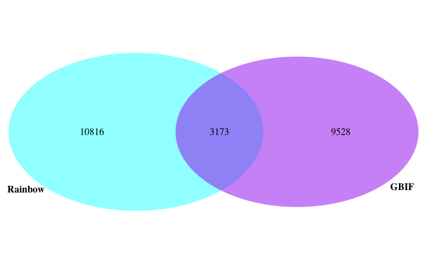

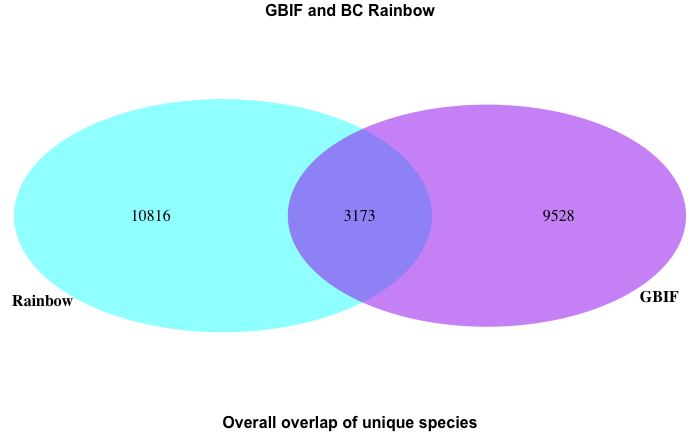

```r
# Plot a venn diagram showing the overlap between unique species on  GBIF and rainbow lists
gbif_rainbow_overlap <- draw.pairwise.venn(area1 = length(gbif_unique_names),
                                           area2 = length(rainbow_unique_names),
                                           cross.area = gbif_rainbow_intersect,
                                            category = c("GBIF", "Rainbow"),
                                           lty = rep("blank", 2),
                                           fill = c("purple", "cyan"),
                                            alpha = rep(0.5,2),
                                            cat.dist = rep(0.025, 2),
                                           scaled = T,
                                           cat.fontface = rep("bold", 2))
# make the ven diagram plot titles
title1 <- textGrob("GBIF and BC Rainbow", gp=gpar(fontface = "bold"))
subtitle1 <- textGrob("Overall overlap of unique species", gp=gpar(fontface = "bold"))
grid.arrange(gTree(children = gbif_rainbow_overlap), top = title1, bottom = subtitle1)
```

```r
# What percent of unique GBIF species are found on rainbow list?
gbif_rainbow_intersect/length(gbif_unique_names)*100
```

```
[1] 24.98228
```

```r
# What percent of the rainbow list is found on GBIF?
gbif_rainbow_intersect/nrow(rainbow_list)*100
```

```
[1] 22.36712
```

```r
# Record the proportion of unqiue species that do not overlap with the other list (ie rainbow or gbif)
prop_gbif_non_overlap <- (length(gbif_unique_names)-gbif_rainbow_intersect)/length(gbif_unique_names)
prop_rainbow_non_overlap <- (length(rainbow_unique_names)-gbif_rainbow_intersect)/length(rainbow_unique_names)
# make a data frame of the relative proportions
prop_data <- data.frame(dataset = c(rep("GBIF",2), rep("Rainbow",2)), catetory = c(rep( c("Unique","Overlap"), 2)),
           prop = c(num_gbif_non_overlap, gbif_rainbow_intersect/length(gbif_unique_names), num_rainbow_non_overlap, gbif_rainbow_intersect/length(rainbow_unique_names)))
```

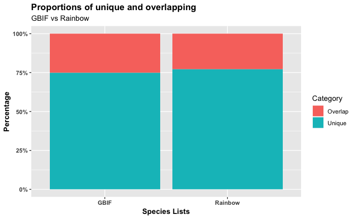

```r
# Make a stacked bar chart indicating the proportion of each list is devoted to the overlap between GBIF and rainbow
ggplot(prop_data, aes(x = dataset, y = prop, fill = catetory))+
      geom_bar(stat = "identity", position = "fill")+
      scale_y_continuous(labels = percent)+
      scale_color_few("Dark", drop = FALSE)+
      labs(x = "Species Lists", y= "Percentage", fill = "Category",
           title = "Proportions of unique and overlapping",
           subtitle = "GBIF vs Rainbow")+
      theme(plot.title = element_text(face = "bold"),
            axis.title.x = element_text(face = "bold"),
            axis.title.y = element_text(face = "bold"),
            axis.text = element_text(face = "bold"))
```

### GBIF and BC Red/Blue

In addition to looking at the proportion of the rainbow list that is included on GBIF, one can also consider the proportion of the Red/Blue listed species alone that are found on GBIF.

```r
# Get the unique species names on the BC red/blue list
red_blue_unique_names <- unique(bc_red_blue$simplified_names)
# How many of GBIF unique species are found on bc_red_blue list?
gbif_red_blue_intersect <- sum(gbif_unique_names%in%red_blue_unique_names);gbif_red_blue_intersect
```

```
[1] 297
```

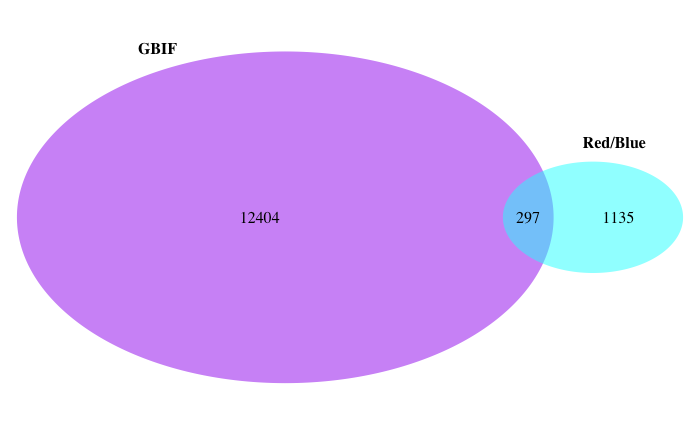

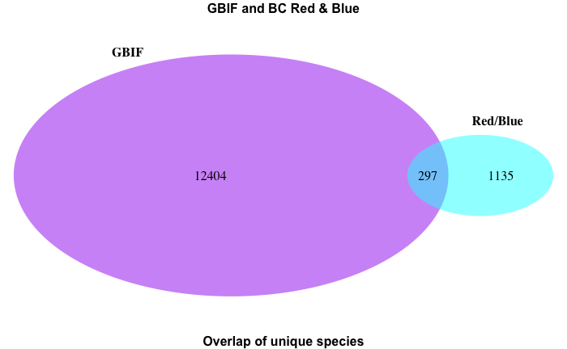

```r
# Plot a venn diagram showing the overlap between unique species on GBIF and BC red/blue lists
gbif_red_blue_overlap <- draw.pairwise.venn(area1 = length(gbif_unique_names),
                                           area2 = length(red_blue_unique_names),
                                           cross.area = gbif_red_blue_intersect,
                                            category = c("GBIF", "Red/Blue"),
                                           lty = rep("blank", 2),
                                           fill = c("purple", "cyan"),
                                            alpha = rep(0.5,2),
                                            cat.dist = rep(0.025, 2),
                                           scaled = T,
                                           cat.fontface = rep("bold", 2),
                                           ext.text = F,
                                           cat.pos = c(-25, 10))
# make the ven diagram plot titles
title2 <- textGrob("GBIF and BC Red & Blue", gp=gpar(fontface = "bold"))
subtitle2 <- textGrob("Overlap of unique species", gp=gpar(fontface = "bold"))
grid.arrange(gTree(children = gbif_red_blue_overlap), top = title2, bottom = subtitle2)
```

```r
# What percent of unique GBIF species are found on bc_red_blue list?
num_gbif_on_redBlue/length(gbif_unique_names)*100
```

```
[1] 2.338399
```

```r
# What percent of the bc_red_blue list species are found on GBIF?
num_gbif_on_redBlue/length(red_blue_unique_names)*100
```

```
[1] 20.74022
```

```r
# Record the proportion of unqiue species that do not overlap with the other list (ie BC red/blue or gbif)
prop_gbif_non_overlap2 <- (length(gbif_unique_names)-gbif_red_blue_intersect)/length(gbif_unique_names)
prop_redBlue_non_overlap <- (length(red_blue_unique_names)-gbif_red_blue_intersect)/length(red_blue_unique_names)
# make a data frame of the relative proportions
prop_data2 <- data.frame(dataset = c(rep("GBIF",2), rep("Red/Blue",2)), catetory = c(rep( c("Unique","Overlap"), 2)),
           prop = c(num_gbif_non_overlap2, gbif_red_blue_intersect/length(gbif_unique_names), num_redBlue_non_overlap, gbif_red_blue_intersect/length(red_blue_unique_names)))
```

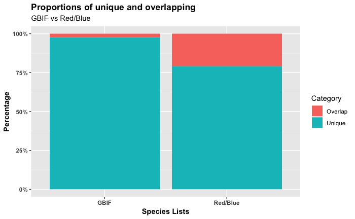

```r
# Make a stacked bar chart indicating the proportion of each list is devoted to the overlap between GBIF and BC red/blue
ggplot(prop_data2, aes(x = dataset, y = prop, fill = catetory))+
      geom_bar(stat = "identity", position = "fill")+
      scale_y_continuous(labels = percent)+
      scale_color_few("Dark", drop = FALSE)+
      labs(x = "Species Lists", y= "Percentage", fill = "Category",
           title = "Proportions of unique and overlapping",
           subtitle = "GBIF vs Red/Blue")+
      theme(plot.title = element_text(face = "bold"),
            axis.title.x = element_text(face = "bold"),
            axis.title.y = element_text(face = "bold"),
            axis.text = element_text(face = "bold"))
```

### Summary

The majority of GBIF species as a whole , ~ 75% are not found on the rainbow list. This top level comparison implies that the BC rainbow list does not represent most of the species in BC. However, there is a sizeable portion of the BC rainbow list that are not found on GBIF. When considering the Red/Blue list separately, ~ 20% of the Red/Blue species are found on GBIF. However, out of the GBIF species, ~ 2% are found on the Red/Blue list.

### GBIF Plants on Rainbow

Breaking down the GBIF into its plant, animal and fungi parts could reveal which of these groups match the rainbow list the most. This could indicate where most of taxonomy incompatibilies lie, or indicate true gaps between rainbow and GBIF.

```r
# Subset GBIF plants
plants_gbif <- filter(trimmed_gbif, kingdom=="Plantae")
# get the unique plant names
plant_gbif_unique_names <- unique(plants_gbif$simplified_names)
# Subset rainbow plants
plants_rainbow <- filter(rainbow_list, Kingdom=="Plantae") %>%
      filter(Phylum!="Mitosporic fungi" & Phylum!="Ascomycota")
# Get unique rainbow plant names
plant_rainbow_unique_names <- unique(plants_rainbow$simplified_names)
```

```r
# Calculate the composition of GBIF and Rainbow in terms of how many plants they have.
# Record the number of unqiue species that are not plants on either list  (ie rainbow or gbif)
prop_gbif_not_plant <- (length(gbif_unique_names)-length(plant_gbif_unique_names))/length(gbif_unique_names)
prop_rainbow_not_plant <- (length(rainbow_unique_names)-length(plant_rainbow_unique_names))/length(rainbow_unique_names)
# make a data frame of the relative proportions
prop_data3 <- data.frame(dataset = c(rep("GBIF",2), rep("Rainbow",2)), catetory = c(rep( c("Non-Plant","Plant"), 2)),
           prop = c(prop_gbif_not_plant, length(plant_gbif_unique_names)/length(gbif_unique_names), prop_rainbow_not_plant,
                    length(plant_rainbow_unique_names)/length(rainbow_unique_names)))
```

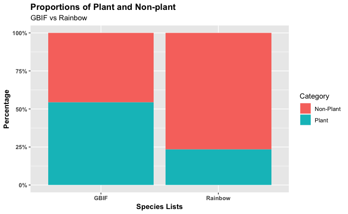

```r
# Make a stacked bar chart indicating the proportion of each list is devoted to plants on GBIF and rainbow
ggplot(prop_data3, aes(x = dataset, y = prop, fill = catetory))+
      geom_bar(stat = "identity", position = "fill")+
      scale_y_continuous(labels = percent)+
      scale_color_few("Dark", drop = FALSE)+
      labs(x = "Species Lists", y= "Percentage", fill = "Category",
           title = "Proportions of Plant and Non-plant",
           subtitle = "GBIF vs Rainbow")+
      theme(plot.title = element_text(face = "bold"),
            axis.title.x = element_text(face = "bold"),
            axis.title.y = element_text(face = "bold"),
            axis.text = element_text(face = "bold"))
```

```r
# How many of the unique GBIF plant species are found on rainbow list?
gbif_plant_on_rainbow <- sum(plants_gbif_unique_names%in%rainbow_unique_names);gbif_plant_on_rainbow
```

```
[1] 1407
```

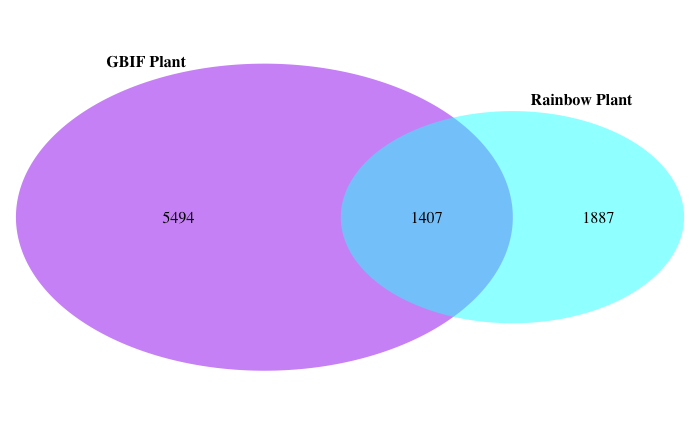

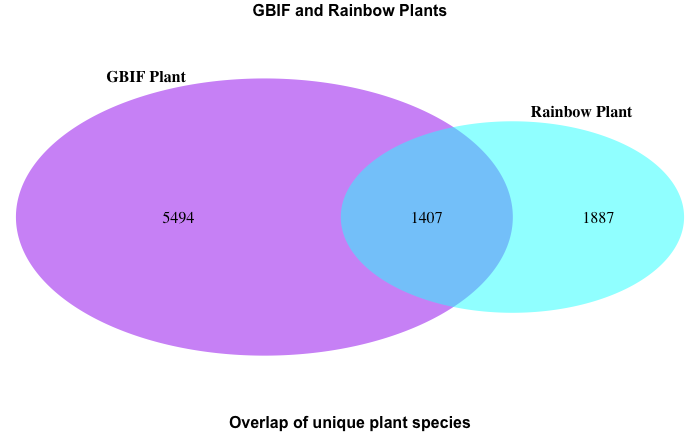

```r
# Plot a venn diagram showing the overlap between unique species on GBIF plant and rainbow plants
gbif_plant_rainbow_overlap <- draw.pairwise.venn(area1 = length(plant_gbif_unique_names),
                                           area2 = length(plant_rainbow_unique_names),
                                           cross.area = gbif_plant_on_rainbow,
                                            category = c("GBIF Plant", "Rainbow Plant"),
                                           lty = rep("blank", 2),
                                           fill = c("purple", "cyan"),
                                            alpha = rep(0.5,2),
                                            cat.dist = rep(0.025, 2),
                                           scaled = T,
                                           cat.fontface = rep("bold", 2),
                                           ext.text = F,
                                           cat.pos = c(-25, 20))
# make the ven diagram plot titles
title3 <- textGrob("GBIF and Rainbow Plants", gp=gpar(fontface = "bold"))
subtitle3 <- textGrob("Overlap of unique plant species", gp=gpar(fontface = "bold"))
grid.arrange(gTree(children = gbif_plant_rainbow_overlap), top = title3, bottom = subtitle3)
```

```r
# What percent of GBIF plants are found on rainbow?
gbif_plant_on_rainbow/length(plant_gbif_unique_names)*100
```

```
[1] 20.38835
```

```r
# What percent of rainbow plants are found on GBIF?
gbif_plant_on_rainbow/length(plant_rainbow_unique_names)*100
```

```
[1] 42.71403
```

```r
# Record the number of unqiue species that do not overlap with the other list (ie rainbow plant or gbif plant)
prop_gbif_non_overlap4 <- (length(plant_gbif_unique_names)-gbif_plant_on_rainbow)/length(plant_gbif_unique_names)
prop_rainbow_non_overlap4 <- (length(plant_rainbow_unique_names)-gbif_plant_on_rainbow)/length(plant_rainbow_unique_names)
# make a data frame of the relative proportions
prop_data4 <- data.frame(dataset = c(rep("GBIF Plant",2), rep("Rainbow Plant",2)), catetory = c(rep( c("Unique","Overlap"), 2)),
           prop = c(num_gbif_non_overlap4, gbif_plant_on_rainbow/length(plant_gbif_unique_names), num_rainbow_non_overlap4,
                    gbif_plant_on_rainbow/length(plant_rainbow_unique_names)))
```

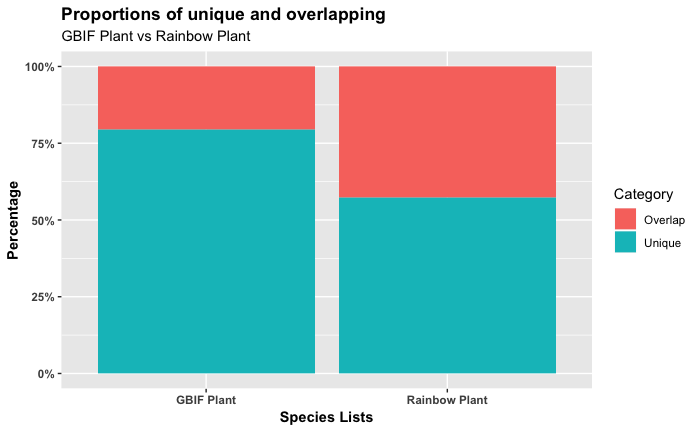

```r
# Make a stacked bar chart indicating the proportion of each list is devoted to the overlap between GBIF and rainbow plants
ggplot(prop_data4, aes(x = dataset, y = prop, fill = catetory))+
      geom_bar(stat = "identity", position = "fill")+
      scale_y_continuous(labels = percent)+
      scale_color_few("Dark", drop = FALSE)+
      labs(x = "Species Lists", y= "Percentage", fill = "Category",
           title = "Proportions of unique and overlapping",
           subtitle = "GBIF Plant vs Rainbow Plant")+
      theme(plot.title = element_text(face = "bold"),
            axis.title.x = element_text(face = "bold"),
            axis.title.y = element_text(face = "bold"),
            axis.text = element_text(face = "bold"))
```

```r
# What percent of GBIF as a whole are the plants found on rainbow?
gbif_plant_on_rainbow/length(na.omit(unique(trimmed_gbif$species)))*100
```

```
[1] 11.07525
```

```r
# What percent of rainbow are the plants found on GBIF?
gbif_plant_on_rainbow/nrow(rainbow_list)*100
```

```
[1] 9.918229
```

### GBIF Animals on Rainbow

```r
# Subset the GBIF animals
animal_gbif <- filter(trimmed_gbif, kingdom=="Animalia")
# Get unique animal names
animal_gbif_unique_names <- unique(animal_gbif$simplified_names)
# Subset the rainbow animals
animal_rainbow <- filter(rainbow_list, Kingdom=="Animalia")
# Get unique animal names from rainbow
animal_rainbow_unique_names <- unique(animal_rainbow$simplified_names)
```

# Is this a useful proportion to think about?

```r
# Animals found on rainbow are what percent of GBIF species?
gbif_animal_on_rainbow/length(gbif_unique_names)*100
```

```
[1] 11.79435
```

```r
# Animals found on GBIF are what percent of Rainbow species?
gbif_animal_on_rainbow/length(rainbow_unique_names)*100
```

```
[1] 10.70841
```

```r
# Calculate the composition of GBIF and Rainbow in terms of how many animals they have.
# Record the number of unqiue species that are not animals on either list  (ie rainbow or gbif)
prop_gbif_not_animal <- (length(gbif_unique_names)-length(animal_gbif_unique_names))/length(gbif_unique_names)
prop_rainbow_not_animal <- (length(rainbow_unique_names)-length(animal_rainbow_unique_names))/length(rainbow_unique_names)
# make a data frame of the relative proportions
prop_data5 <- data.frame(dataset = c(rep("GBIF",2), rep("Rainbow",2)), catetory = c(rep( c("Non-Animal","Animal"), 2)),
           prop = c(prop_gbif_not_animal, length(animal_gbif_unique_names)/length(gbif_unique_names), prop_rainbow_not_animal,
                    length(animal_rainbow_unique_names)/length(rainbow_unique_names)))
```

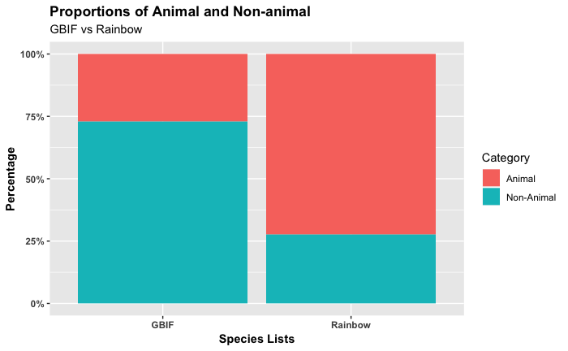

```r
# Make a stacked bar chart indicating the proportion of each list is devoted to animals on GBIF and rainbow
ggplot(prop_data5, aes(x = dataset, y = prop, fill = catetory))+
      geom_bar(stat = "identity", position = "fill")+
      scale_y_continuous(labels = percent)+
      scale_color_few("Dark", drop = FALSE)+
      labs(x = "Species Lists", y= "Percentage", fill = "Category",
           title = "Proportions of Animal and Non-animal",
           subtitle = "GBIF vs Rainbow")+
      theme(plot.title = element_text(face = "bold"),
            axis.title.x = element_text(face = "bold"),
            axis.title.y = element_text(face = "bold"),
            axis.text = element_text(face = "bold"))
```

```r
# How many of the unique GBIF animal species are found on rainbow list?
gbif_animal_on_rainbow <- sum(animal_gbif_unique_names%in%rainbow_unique_names);gbif_animal_on_rainbow
```

```
[1] 1498
```

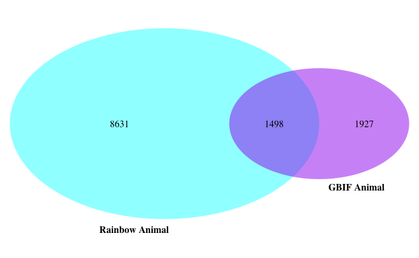

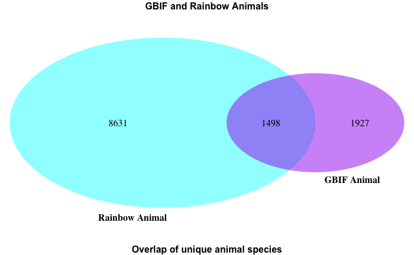

```r
# Plot a venn diagram showing the overlap between unique species on GBIF animal and rainbow animals
gbif_animal_rainbow_overlap <- draw.pairwise.venn(area1 = length(animal_gbif_unique_names),
                                           area2 = length(animal_rainbow_unique_names),
                                           cross.area = gbif_animal_on_rainbow,
                                            category = c("GBIF Animal", "Rainbow Animal"),
                                           lty = rep("blank", 2),
                                           fill = c("purple", "cyan"),
                                            alpha = rep(0.5,2),
                                            cat.dist = rep(0.025, 2),
                                           scaled = T,
                                           cat.fontface = rep("bold", 2),
                                           ext.text = F,
                                           cat.pos = c(-20, 10))
# make the ven diagram plot titles
title4 <- textGrob("GBIF and Rainbow Animals", gp=gpar(fontface = "bold"))
subtitle4 <- textGrob("Overlap of unique animal species", gp=gpar(fontface = "bold"))
grid.arrange(gTree(children = gbif_animal_rainbow_overlap), top = title4, bottom = subtitle4)
```

```r
# What percent of GBIF animal are found on rainbow?
gbif_animal_on_rainbow/length(animal_gbif_unique_names)*100
```

```
[1] 43.73723
```

```r
# What percent of Rainbow animal list is the overlap with GBIF?
gbif_animal_on_rainbow/length(animal_rainbow_unique_names)*100
```

```
[1] 14.78922
```

```r
# Record the number of unqiue species that do not overlap with the other list (ie rainbow animal or gbif animal)
prop_gbif_non_overlap6 <- (length(animal_gbif_unique_names)-gbif_animal_on_rainbow)/length(animal_gbif_unique_names)
prop_rainbow_non_overlap6 <- (length(animal_rainbow_unique_names)-gbif_animal_on_rainbow)/length(animal_rainbow_unique_names)
# make a data frame of the relative proportions
prop_data6 <- data.frame(dataset = c(rep("GBIF Animal",2), rep("Rainbow Animal",2)), catetory = c(rep( c("Unique","Overlap"), 2)),
           prop = c(num_gbif_non_overlap4, gbif_animal_on_rainbow/length(animal_gbif_unique_names), num_rainbow_non_overlap4,
                    gbif_animal_on_rainbow/length(animal_rainbow_unique_names)))
```

[figure not shown]

```r
# Make a stacked bar chart indicating the proportion of each list is devoted to the overlap between GBIF and rainbow animals
ggplot(prop_data6, aes(x = dataset, y = prop, fill = catetory))+
      geom_bar(stat = "identity", position = "fill")+
      scale_y_continuous(labels = percent)+
      scale_color_few("Dark", drop = FALSE)+
      labs(x = "Species Lists", y= "Percentage", fill = "Category",
           title = "Proportions of unique and overlapping",
           subtitle = "GBIF Animal vs Rainbow Animal")+
      theme(plot.title = element_text(face = "bold"),
            axis.title.x = element_text(face = "bold"),
            axis.title.y = element_text(face = "bold"),
            axis.text = element_text(face = "bold"))
```

### GBIF Fungi on Rainbow

```r
# Subset the GBIF fungi
fungi_gbif <- filter(trimmed_gbif, kingdom=="Fungi")
# Get the unqiue fungi names
fungi_gbif_unique_names <- unique(fungi_gbif$simplified_names)
# Subst the rainbow fungi
fungi_rainbow <- filter(rainbow_list, Phylum=="Mitosporic fungi" | Phylum=="Ascomycota")
# Get the unique fungi names
fungi_rainbow_unique_names <- unique(fungi_rainbow$simplified_names)
```

```r
# Unqiue fungi species are what percent of the GBIF unique species?
length(fungi_gbif_unique_names)/length(gbif_unique_names)*100
```

```
[1] 16.67585
```

```r
# Calculate the composition of GBIF and Rainbow in terms of how many fungi they have.
# Record the number of unqiue species that are not fungi on either list  (ie rainbow or gbif)
prop_gbif_not_fungi <- (length(gbif_unique_names)-length(fungi_gbif_unique_names))/length(gbif_unique_names)
prop_rainbow_not_fungi <- (length(rainbow_unique_names)-length(fungi_rainbow_unique_names))/length(rainbow_unique_names)
# make a data frame of the relative proportions
prop_data7 <- data.frame(dataset = c(rep("GBIF",2), rep("Rainbow",2)), catetory = c(rep( c("Non-Fungi","Fungi"), 2)),
           prop = c(prop_gbif_not_fungi, length(fungi_gbif_unique_names)/length(gbif_unique_names), prop_rainbow_not_fungi,
                    length(fungi_rainbow_unique_names)/length(rainbow_unique_names)))
```

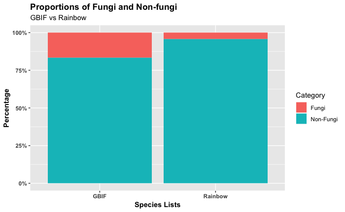

```r
# Make a stacked bar chart indicating the proportion of each list is devoted to plants on GBIF and rainbow
ggplot(prop_data7, aes(x = dataset, y = prop, fill = catetory))+
      geom_bar(stat = "identity", position = "fill")+
      scale_y_continuous(labels = percent)+
      scale_color_few("Dark", drop = FALSE)+
      labs(x = "Species Lists", y= "Percentage", fill = "Category",
           title = "Proportions of Fungi and Non-fungi",
           subtitle = "GBIF vs Rainbow")+
      theme(plot.title = element_text(face = "bold"),
            axis.title.x = element_text(face = "bold"),
            axis.title.y = element_text(face = "bold"),
            axis.text = element_text(face = "bold"))
```

```r
# How many of the unique GBIF fungi species are found on rainbow list?
gbif_fungi_on_rainbow <- sum(na.omit(unique(fungi_gbif$species))%in%rainbow_list$Scientific.Name);gbif_fungi_on_rainbow
```

```
[1] 260
```

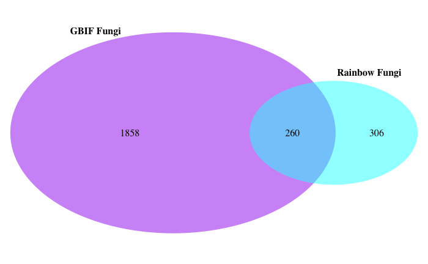

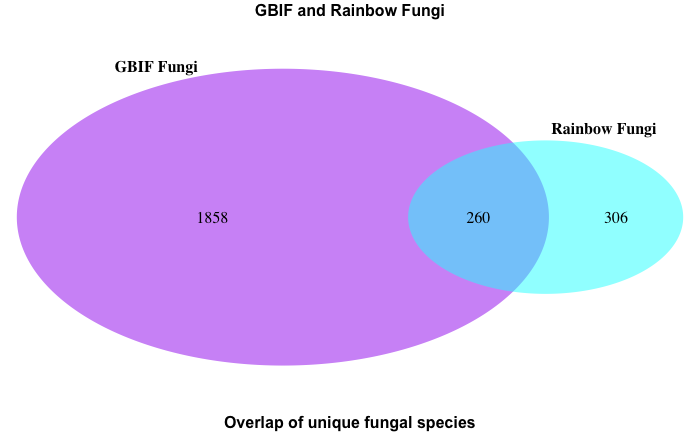

```r
# Plot a venn diagram showing the overlap between unique species on GBIF fungi and rainbow fungi
gbif_fungi_rainbow_overlap <- draw.pairwise.venn(area1 = length(fungi_gbif_unique_names),
                                           area2 = length(fungi_rainbow_unique_names),
                                           cross.area = gbif_fungi_on_rainbow,
                                            category = c("GBIF Fungi", "Rainbow Fungi"),
                                           lty = rep("blank", 2),
                                           fill = c("purple", "cyan"),
                                            alpha = rep(0.5,2),
                                            cat.dist = rep(0.025, 2),
                                           scaled = T,
                                           cat.fontface = rep("bold", 2),
                                           ext.text = F,
                                           cat.pos = c(-25, 20))
# make the ven diagram plot titles
title5 <- textGrob("GBIF and Rainbow Fungi", gp=gpar(fontface = "bold"))
subtitle5 <- textGrob("Overlap of unique fungal species", gp=gpar(fontface = "bold"))
grid.arrange(gTree(children = gbif_fungi_rainbow_overlap), top = title5, bottom = subtitle5)
```

```r
# What percent of GBIF fungi are found on rainbow?
gbif_fungi_on_rainbow/length(fungi_gbif_unique_names)*100
```

```
[1] 12.27573
```

```r
# What percent of Rainbow fungi are found on GBIF?
gbif_fungi_on_rainbow/length(fungi_rainbow_unique_names)*100
```

```
[1] 45.9364
```

```r
# Record the proportion of unqiue species that do not overlap with the other list (ie rainbow fungi or gbif fungi)
prop_gbif_non_overlap8 <- (length(fungi_gbif_unique_names)-gbif_fungi_on_rainbow)/length(fungi_gbif_unique_names)
prop_rainbow_non_overlap8 <- (length(fungi_rainbow_unique_names)-gbif_fungi_on_rainbow)/length(fungi_rainbow_unique_names)
# make a data frame of the relative proportions
prop_data8 <- data.frame(dataset = c(rep("GBIF Fungi",2), rep("Rainbow Fungi",2)), catetory = c(rep( c("Unique","Overlap"), 2)),
           prop = c(prop_gbif_non_overlap8, gbif_fungi_on_rainbow/length(fungi_gbif_unique_names), prop_rainbow_non_overlap8,
                    gbif_fungi_on_rainbow/length(fungi_rainbow_unique_names)))
```

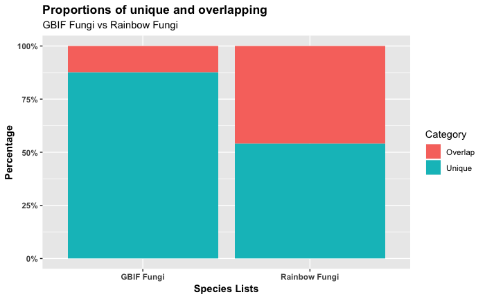

```r
# Make a stacked bar chart indicating the proportion of each list is devoted to the overlap between GBIF and rainbow fungi
ggplot(prop_data8, aes(x = dataset, y = prop, fill = catetory))+
      geom_bar(stat = "identity", position = "fill")+
      scale_y_continuous(labels = percent)+
      scale_color_few("Dark", drop = FALSE)+
      labs(x = "Species Lists", y= "Percentage", fill = "Category",
           title = "Proportions of unique and overlapping",
           subtitle = "GBIF Fungi vs Rainbow Fungi")+
      theme(plot.title = element_text(face = "bold"),
            axis.title.x = element_text(face = "bold"),
            axis.title.y = element_text(face = "bold"),
            axis.text = element_text(face = "bold"))
```

# is this a useful proportion?

```r
# Fungi found on rainbow are what percent of GBIF species?
gbif_fungi_on_rainbow/length(fungi_gbif_unique_names)*100

# What percent of the rainbow list are the fungi species found on GBIF?
gbif_fungi_on_rainbow/length(fungi_rainbow_unique_names)*100
```

# Conclusion:

25% of GBIF is found on rainbow list. 22% of the rainbow list is found on GBIF

2% are fungi

10% are plants

12% are animals

20% of gbif plants are found on rainbow

44% of gbif animals are found on rainbow

12% of gbif fungi are found on rainbow

```r
# With var. removed from both gbif and rainbow, how many of the unique GBIF species are found on rainbow list?
gbif_rainbow_intersect <- sum(na.omit(unique(trimmed_gbif$simplified_names))%in%unique(rainbow_list$simplified_names));gbif_rainbow_intersect

# How many additional species does this allow to match?
num_gbif_on_rainbow-sum(unique(trimmed_gbif$species)%in%rainbow_list$Scientific.Name)
```

# Rainbow List and IUCN Comparison

```r
# How many species on bc_red_blue list are on the IUCN?
bc_red_blue_on_IUCN <- sum(unique(bc_red_blue$simplified_names)%in%unique(IUCN_list$simplified_names));bc_red_blue_on_IUCN

# What percent of the BC_red_blue list are on IUCN?
bc_red_blue_on_IUCN/length(unique(bc_red_blue$simplified_names))*100
```

# GBIF and IUCN Comparison

```r
# How many of the IUCN red list species are found on GBIF?
num_gbif_on_IUCN <- sum(unique(IUCN_list$simplified_names)%in%unique(na.omit(trimmed_gbif$simplified_names)));num_gbif_on_IUCN

# what percent of the IUCN list is found on gbif
num_gbif_on_IUCN/length(IUCN_list$simplified_names)*100

# What percent of the GBIF is found on IUCN?
num_gbif_on_IUCN/length(na.omit(unique(trimmed_gbif$simplified_names)))*100
```

# Taxonomic Name Resolution

```r
# GBIF plant species list fed into TNRS
plant_species <- unique(plants_gbif$species)

# Rainbow plant species list fed into TNRS
# subset rainbow plants
rainbow_plants <- filter(rainbow_list, Kingdom=="Plantae") %>%
      filter(Phylum!="Mitosporic fungi" & Phylum!="Ascomycota")

# Get rainbow plant species list fed into TNRS
rainbow_plant_names <- rainbow_plants$Scientific.Name
```

```r
# read in the GBIF TNRS results
gbif_tnrs <- read.csv("gbif_plant_tnrs_results.csv", na.strings = c("", " "), stringsAsFactors = F)

# select most relevant columns
gbif_tnrs_trim <- select(gbif_tnrs, c(Name_number,
                                            Name_submitted,
                                            Overall_score,
                                            Name_matched,
                                            Name_matched_rank,
                                            Name_matched_author,
                                            Name_score,
                                            Genus_score,
                                            Specific_epithet_matched,
                                            Specific_epithet_score,
                                            Unmatched_terms,
                                            Taxonomic_status,
                                            Accepted_name,
                                            Accepted_name_rank,
                                            Warnings))
# strip out var. from all Accepted_names
gbif_tnrs_trim <- mutate(gbif_tnrs_trim, simplified_accepted_names = gsub(pattern = " var.*", replacement = "",
                                                                                x = gbif_tnrs_trim$Accepted_name))
```

```r
# Read in the rainbow TNRS results
rainbow_tnrs <- read.csv("rainbow_plant_tnrs.csv", na.strings = c("", " "), stringsAsFactors = F)

# select the most relevant colums
rainbow_tnrs_trim <- select(rainbow_tnrs, c(Name_number,
                                            Name_submitted,
                                            Overall_score,
                                            Name_matched,
                                            Name_matched_rank,
                                            Name_matched_author,
                                            Name_score,
                                            Genus_score,
                                            Specific_epithet_matched,
                                            Specific_epithet_score,
                                            Unmatched_terms,
                                            Taxonomic_status,
                                            Accepted_name,
                                            Accepted_name_rank,
                                            Warnings))

# strip out var. from all Accpeted_names
rainbow_tnrs_trim <- mutate(rainbow_tnrs_trim, simplified_accepted_names = gsub(pattern = " var.*", replacement = "",
                                                                                x = rainbow_tnrs_trim$Accepted_name))
```

```r
# How many of the rainbow_tnrs "Accepted names" are on the gbif_tnrs "Accepted names" ?
sum(unique(rainbow_tnrs_trim$Accepted_name)%in%unique(gbif_tnrs_trim$Accepted_name))

# What percent of the rainbow plant names are mapped to "Accepted_names" that are also found on gbif_tnrs "Accepted_names"?
sum(unique(rainbow_tnrs_trim$Accepted_name)%in%unique(gbif_tnrs_trim$Accepted_name))/length(rainbow_plant_names)*100


# What percent of the gbif plants map to "Accepted_names" that are found on rainbow_tnrs "Accepted_names"?
sum(unique(rainbow_tnrs_trim$Accepted_name)%in%unique(gbif_tnrs_trim$Accepted_name))/length(plant_species)*100


# What percent of gbif plants matched with rainbow before name correction?
sum(plant_species%in%rainbow_list$Scientific.Name)/length(plant_species)*100


# after stripping out var. from both rainbow and gbif, what percent of rainbow match?
sum(unique(rainbow_tnrs_trim$simplified_accepted_names)%in%unique(gbif_tnrs_trim$simplified_accepted_names))/length(rainbow_plant_names)*100

# Note: stripping out var. only increased the matching by 1.6%
```

### Add corrected GBIF names to rainbow list

```r
# Get the gbif_tnrs that have a taxon_status of "Synonym"
gbif_synonym_status <- filter(gbif_tnrs_trim, Taxonomic_status=="Synonym" & Overall_score==1)

# Get the indices on rainbow that have a "Accepted_name" match to gbif_synonym_status
i <- which(unique(rainbow_tnrs_trim$simplified_accepted_names)%in%unique(gbif_synonym_status$simplified_accepted_name))

# Get the indices on rainbow that did not have an "Accepted_name" match with gbif_synonym_status
j <- which(!unique(rainbow_tnrs_trim$simplified_accepted_names)%in%unique(gbif_synonym_status$simplified_accepted_name))

# Get the indices from gbif_synonym_status that have an "Accepted_name" match with rainbow
m <- which(unique(gbif_synonym_status$simplified_accepted_names)%in%unique(rainbow_tnrs_trim$simplified_accepted_names))

# Make a dataframe that contains rainbow matches to gbif_synonym_status, adding a column for gbif corrected names
rain1 <- cbind(rainbow_tnrs_trim[i,], gbif_synonym_status[m,]$Name_submitted)
colnames(rain1)[17] <- "gbif_corrected_name"

# Make a dataframe that contains the rainbow non-matches to gbif_synonym_status, adding a column for gbif submitted names
rain2 <- cbind(rainbow_tnrs_trim[j,], rainbow_tnrs_trim[j,]$simplified_accepted_names)
colnames(rain2)[17] <- "gbif_corrected_name"

rain2 <- cbind(rainbow_tnrs_trim[j,], rep(NA, nrow(rainbow_tnrs_trim[j,])))
colnames(rain2)[17] <- "gbif_corrected_name"

# re-create the full rainbow_tns_trim with the gbif corrected names added
# Note: this data frame has had duplicate "simplified_accepted_name" removed
corrected_rainbow_tnrs_trim <- rbind(rain1, rain2)
```

```r
# test case

df1_gbif <- data.frame(taxon_status = c("Accepted", "Accepted", "Synonym", "Synonym", "Synonym", "Accepted", "Accepted", "Synonym", "Synonym"),
                       simplified_accepted_name = c("Sandra c", "Jane d", "Sally o", "Becky m", "Sally o","Becky m", "Tally h", "Nada l", "Masha e"),
                       submitted_matched_name = c("Sandra c", "Jane d", "Sally a", "Becky a", "Sally a", "Becky m", "Tally h", "Nada b", "Masha b"))

df2_rainbow <- data.frame(taxon_status = c("Accepted", "Accepted", "Synonym", "Accepted", "Synonym", "Accepted", "Accepted", "Synonym"),
                          simplified_accepted_name = c("Sally o", "Donna x", "Becky m", "Jade l", "Teal s", "Sally o", "Nada l", "Tally h"))

df1_alt <- filter(df1_gbif, taxon_status=="Synonym")

i <- which(df2_rainbow$simplified_accepted_name%in%df1_alt$simplified_accepted_name)

m <- which(df1_alt$simplified_accepted_name%in%df2_rainbow$simplified_accepted_name)

j <- which(!df2_rainbow$simplified_accepted_name%in%df1_alt$simplified_accepted_name)

rain1 <- cbind(df2_rainbow[i,], df1_alt[m,]$submitted_matched_name)
colnames(rain1) <- c("taxon_staus", "simplified_accepted_name", "gbif name")

rain2 <- cbind(df2_rainbow[j,], df2_rainbow[j,]$simplified_accepted_name)
colnames(rain2) <- c("taxon_staus", "simplified_accepted_name", "gbif_name")

rbind(rain1, rain2)
```